# SAP projekt - Analiza poadataka o igračima NHL lige

```r
sapply(fiveOnFour, class)
```

```
  Last.Name  First.Name    Position        Team          GP           G           A          A1         PTS      PTS.60        IPP.         TOI
"character" "character" "character" "character"   "integer"   "integer"   "integer"   "integer"   "integer"   "numeric" "character"   "integer"
      TOI.1       TOI.2      TOI.GP        TOI.         ZS.      RelZS.     TOI.QoT     TOI.QoC      CF.QoC         SH.         SV.         PDO
  "numeric"   "numeric"   "numeric" "character" "character" "character" "character" "character" "character" "character"   "numeric"   "integer"
       F.60        A.60        Pct.        Diff     Diff.60     RelF.60     RelA.60     RelPct.    RelDf.60         iCF         iFF         iSF
  "numeric"   "numeric" "character"   "integer"   "numeric"   "numeric"   "numeric" "character"   "numeric"   "integer"   "integer"   "integer"
      iSF.1         ixG        iSCF       iCF.1       iFF.1       iSF.2         iRB         iRS         iDS       sDist        Pass         iHF
  "integer"   "numeric"   "integer"   "integer"   "integer"   "integer"   "integer"   "integer"   "integer"   "numeric"   "numeric"   "integer"
      iHF.1         iHA        iHDf       iMiss        iGVA        iTKA      iGVA.1      iTKA.1        iBLK        BLK.        iFOW        iFOL
  "integer"   "integer"   "integer"   "integer"   "integer"   "integer"   "integer"   "integer"   "integer" "character"   "integer"   "integer"
     iFOW.1      iFOL.1         FO.       X.FOT       iPENT       iPEND      iPenDf         OZS         DZS         NZS         OTF       OZS.1
  "integer"   "integer" "character" "character"   "integer"   "integer"   "integer"   "integer"   "integer"   "integer"   "integer"   "integer"
      DZS.1       NZS.1         OZF         DZF         NZF          CF          CA          FF          FA          SF          SA         xGF
  "integer"   "integer"   "integer"   "integer"   "integer"   "integer"   "integer"   "integer"   "integer"   "integer"   "integer"   "numeric"
        xGA         SCF         SCA          GF          GA         RBF         RBA         RSF         RSA         DSF         DSA        CF.1
  "numeric"   "integer"   "integer"   "integer"   "integer"   "integer"   "integer"   "integer"   "integer"   "integer"   "integer"   "integer"
       CA.1        FF.1        FA.1        SF.1        SA.1        GF.1        GA.1         FOW         FOL          HF          HA         GVA
  "integer"   "integer"   "integer"   "integer"   "integer"   "integer"   "integer"   "integer"   "integer"   "integer"   "integer"   "integer"
        TKA        PENT        PEND        OTOI         OCF         OCA         OFF         OFA         OSF         OSA        OxGF        OxGA
  "integer"   "integer"   "integer"   "numeric"   "integer"   "integer"   "integer"   "integer"   "integer"   "integer"   "numeric"   "numeric"
       OSCF        OSCA         OGF         OGA        OOZS        ODZS        ONZS      TMCF60      TMCA60      TMFF60      TMFA60      TMSF60
  "integer"   "integer"   "integer"   "integer"   "integer"   "integer"   "integer"   "numeric"   "numeric"   "numeric"   "numeric"   "numeric"
     TMSA60      TMGF60      TMGA60   TOI.QoT.1      CF.QoT     xGF.QoT     OppCF60     OppCA60     OppFF60     OppFA60     OppSF60     OppSA60
  "numeric"   "numeric"   "numeric"   "numeric"   "numeric"   "numeric"   "numeric"   "numeric"   "numeric"   "numeric"   "numeric"   "numeric"
    OppGF60     OppGA60   TOI.QoC.1    CF.QoC.1     xGF.QoC        Pace
  "numeric"   "numeric"   "numeric"   "numeric"   "numeric"   "numeric"
```

```r
sapply(fourOnFive, class)
```

```
  Last.Name  First.Name    Position        Team          GP           G           A          A1         PTS         TOI       TOI.1       TOI.2
"character" "character" "character" "character"   "integer"   "integer"   "integer"   "integer"   "integer"   "integer"   "numeric"   "numeric"
     TOI.GP        TOI.         ZS.      RelZS.     TOI.QoT     TOI.QoC      CF.QoC         SH.         SV.         PDO        F.60        A.60
  "numeric" "character" "character" "character" "character" "character" "character" "character"   "numeric"   "integer"   "numeric"   "numeric"
       Pct.        Diff     Diff.60     RelF.60     RelA.60     RelPct.    RelDf.60         iCF         iFF         iSF       iSF.1         ixG
"character"   "integer"   "numeric"   "numeric"   "numeric" "character"   "numeric"   "integer"   "integer"   "integer"   "integer"   "numeric"
       iSCF       iCF.1       iFF.1       iSF.2         iRB         iRS         iDS       sDist        Pass         iHF       iHF.1         iHA
  "integer"   "integer"   "integer"   "integer"   "integer"   "integer"   "integer"   "numeric" "character"   "integer"   "integer"   "integer"
       iHDf       iMiss        iGVA        iTKA        iBLK      iGVA.1      iTKA.1      iBLK.1        BLK.        iFOW        iFOL      iFOW.1
  "integer"   "integer"   "integer"   "integer"   "integer"   "integer"   "integer"   "integer" "character"   "integer"   "integer"   "integer"
     iFOL.1         FO.       X.FOT       iPENT       iPEND      iPenDf         OZS         DZS         NZS         OTF       OZS.1       DZS.1
  "integer" "character" "character"   "integer"   "integer"   "integer"   "integer"   "integer"   "integer"   "integer"   "integer"   "integer"
      NZS.1         OZF         DZF         NZF          CF          CA          FF          FA          SF          SA         xGF         xGA
  "integer"   "integer"   "integer"   "integer"   "integer"   "integer"   "integer"   "integer"   "integer"   "integer"   "numeric"   "numeric"
        SCF         SCA          GF          GA         RBF         RBA         RSF         RSA         DSF         DSA        CF.1        CA.1
  "integer"   "integer"   "integer"   "integer"   "integer"   "integer"   "integer"   "integer"   "integer"   "integer"   "integer"   "integer"
       FF.1        FA.1        SF.1        SA.1        GF.1        GA.1         FOW         FOL          HF          HA         GVA         TKA
  "integer"   "integer"   "integer"   "integer"   "integer"   "integer"   "integer"   "integer"   "integer"   "integer"   "integer"   "integer"
       PENT        PEND        OTOI         OCF         OCA         OFF         OFA         OSF         OSA        OxGF        OxGA        OSCF
  "integer"   "integer"   "numeric"   "integer"   "integer"   "integer"   "integer"   "integer"   "integer"   "numeric"   "numeric"   "integer"
       OSCA         OGF         OGA        OOZS        ODZS        ONZS      TMCF60      TMCA60      TMFF60      TMFA60      TMSF60      TMSA60
  "integer"   "integer"   "integer"   "integer"   "integer"   "integer"   "numeric"   "numeric"   "numeric"   "numeric"   "numeric"   "numeric"
     TMGF60      TMGA60   TOI.QoT.1      CF.QoT     xGF.QoT     OppCF60     OppCA60     OppFF60     OppFA60     OppSF60     OppSA60     OppGF60
  "numeric"   "numeric"   "numeric"   "numeric"   "numeric"   "numeric"   "numeric"   "numeric"   "numeric"   "numeric"   "numeric"   "numeric"
    OppGA60   TOI.QoC.1    CF.QoC.1     xGF.QoC        Pace
  "numeric"   "numeric"   "numeric"   "numeric"   "numeric"
```

```r
sapply(Goalies, class)
```

```
  Last.Name  First.Name     Team.s.         DOB  Birth.City         S.P       Cntry         Nat          Ht          Wt          Sh      Dft.Yr
"character" "character" "character" "character" "character" "character" "character" "character"   "integer"   "integer" "character"   "integer"
         Rd        Ovrl          GP          GS          GR           W           L           T         OTL          SA          SV          GA
  "integer"   "integer"   "integer"   "integer"   "integer"   "integer"   "integer"   "integer"   "integer"   "integer"   "integer"   "integer"
        SV.         GAA        GSAA         MIN          SO           G           A         PTS         PIM        PenT        PenD       PenDf
  "numeric"   "numeric"   "numeric"   "numeric"   "integer"   "integer"   "integer"   "integer"   "integer"   "integer"   "integer"   "integer"
       Supp         QoC       StMin        StSV        StGA       StSV.       StGAA          QS         QS.         RBS        Pull       ReMin
  "numeric" "character"   "numeric"   "integer"   "integer"   "numeric"   "numeric"   "integer" "character"   "integer"   "integer"   "numeric"
       ReSV        ReGA       ReSV.       ReGAA        Dist         Reb        Rush          DS       HighS       HighG     HighSV.        MedS
  "integer"   "integer"   "numeric"   "numeric"   "numeric"   "integer"   "integer"   "integer"   "integer"   "integer"   "numeric"   "integer"
       MedG        LowS        LowG      AdjSV.        EVSA        EVGA      EV.SV.       PP.SA       PP.GA      PP.SV.       SH.SA       SH.GA
  "integer"   "integer"   "integer"   "numeric"   "integer"   "integer"   "numeric"   "integer"   "integer"   "numeric"   "integer"   "integer"
     SH.SV.    AdjSV..1          CA          FA        SA.1         xGA        GA.1     TrueSV.      ExpSV.       xGSAA         ZS.         OZS
  "numeric"   "numeric"   "integer"   "integer"   "integer"   "numeric"   "integer"   "numeric"   "numeric"   "numeric" "character"   "integer"
        DZS         NZS          CF          FF          SF         xGF          GF        RebF       RushF         SOS         SOG      SO.SV.
  "integer"   "integer"   "integer"   "integer"   "integer"   "numeric"   "integer"   "integer"   "integer"   "integer"   "integer"   "numeric"
        SOW         SOL         NMC      Status      Salary     Cap.Hit        Pace        X1st        X2nd        X3rd        Star         GPS
  "integer"   "integer" "character" "character" "character" "character"   "numeric"   "integer"   "integer"   "integer"   "integer"   "numeric"
       Ginj    Injuries        CHIP
  "integer" "character" "character"
```

```r
sapply(fiveVsfive, class)
```

```
 First.Name   Last.Name        Team         TOI         GAA        GSAA         SV.     TrueSV.      ExpSV.       xGSAA          CA          FA
"character" "character" "character"   "numeric"   "numeric"   "numeric"   "numeric"   "numeric"   "numeric"   "numeric"   "integer"   "integer"
         SA         xGA          GA       HighS       HighG     HighSV.        MedS        MedG        LowS        LowG      AdjSV.        Dist
  "integer"   "numeric"   "integer"   "integer"   "integer"   "numeric"   "integer"   "integer"   "integer"   "integer"   "numeric"   "numeric"
        Reb        Rush          DS        PenT        PenD       PenDf          CF          FF          SF         xGF          GF        RebF
  "integer"   "integer"   "integer"   "integer"   "integer"   "integer"   "integer"   "integer"   "integer"   "numeric"   "integer"   "integer"
      RushF        Supp         ZS.         OZS         DZS         NZS
  "integer"   "numeric" "character"   "integer"   "integer"   "integer"
```

### Plaće NHL igrača

Nakon što smo se upoznali s podacima, možemo se prebaciti na analizu.Jedna od najvažnijih stavki svakog zaposlenog čovjeka, iznos novca kojeg dobije za svoj rad.Stoga ćemo se u ovom dijelu koncentrirati na zadatke vezane uz plaće.Stoga će naš prvi zadatak bit: Možemo li uočiti nekakvu distribuciju plaća NHL igrača?

###ZADATAK 1 ###DISTRIBUCIJA PLAĆE

```r
require(stringr)
### IZDVAJANJE U ZASEBNE ZABLICE PLAĆE IGRAČA
### 3 TABLICE:IGRAČI+GOLMANI, IGRAČI I GOLMANI
playersSalary <- as.data.frame(AllSits[, c("Last.Name", "First.Name","Hand","Position","Salary")])
goaliesSalary <- as.data.frame(Goalies[, c("Last.Name", "First.Name", "Salary")])
goaliesSalary$Position <- "GK"
goaliesSalary$Hand <- NA

salary <- rbind(playersSalary, goaliesSalary)

salary$Salary <- str_remove(salary$Salary, "[$]")
playersSalary$Salary <- str_remove(playersSalary$Salary, "[$]")
goaliesSalary$Salary <- str_remove(goaliesSalary$Salary, "[$]")

salary$Salary <- str_replace_all(salary$Salary, "[.]", "")
playersSalary$Salary <- str_replace_all(playersSalary$Salary, "[.]", "")
goaliesSalary$Salary <- str_replace_all(goaliesSalary$Salary, "[.]", "")

salary$Salary <- str_replace_all(salary$Salary, "[,]", ".")
playersSalary$Salary <- str_replace_all(playersSalary$Salary, "[,]", ".")
goaliesSalary$Salary <- str_replace_all(goaliesSalary$Salary, "[,]", ".")

salary$Salary <- as.numeric(salary$Salary)
playersSalary$Salary <- as.numeric(playersSalary$Salary)
goaliesSalary$Salary <- as.numeric(goaliesSalary$Salary)

### Plaće podijeljene s milijun
salary$Salary <- salary$Salary / 1e6
playersSalary$Salary <- playersSalary$Salary / 1e6
goaliesSalary$Salary <- goaliesSalary$Salary / 1e6

### postotak redaka kojima je salary NA
sum(is.na(salary$Salary)) / nrow(salary)
```

```
[1] 0.02034588
```

```r
sum(is.na(playersSalary$Salary)) / nrow(playersSalary)
```

```
[1] 0.01576577
```

```r
sum(is.na(goaliesSalary$Salary)) / nrow(goaliesSalary)
```

```
[1] 0.06315789
```

```r
###  odbacujemo one retke u kojima je salary postavljena na NA zbog prethodno dobivenih malih postotaka
salary_pure <- as.data.frame(salary[complete.cases(salary$Salary), ])
playersSalary_pure <- as.data.frame(playersSalary[complete.cases(playersSalary$Salary), ])
goaliesSalary_pure <- as.data.frame(goaliesSalary[complete.cases(goaliesSalary$Salary), ])
```

### Mjere centralne tendencije vezane uz plaću

Izračunat ćemo neke standradne mjere poput max,min, srednje vrijednosti, medijana, kvartila

```r
###max i min
max(salary_pure$Salary)
```

```
[1] 14
```

```r
min(salary_pure$Salary)
```

```
[1] 0.575
```

```r
max(playersSalary_pure$Salary)
```

```
[1] 14
```

```r
min(playersSalary_pure$Salary)
```

```
[1] 0.575
```

```r
max(goaliesSalary_pure$Salary)
```

```
[1] 9.5
```

```r
min(goaliesSalary_pure$Salary)
```

```
[1] 0.575
```

```r
### Aritmeticka sredina
mean(salary_pure$Salary)
```

```
[1] 2.349043
```

```r
mean(playersSalary_pure$Salary)
```

```
[1] 2.325289
```

```r
mean(goaliesSalary_pure$Salary)
```

```
[1] 2.582316
```

```r
### Medijan
median(salary_pure$Salary)
```

```
[1] 0.925
```

```r
median(playersSalary_pure$Salary)
```

```
[1] 0.925
```

```r
median(goaliesSalary_pure$Salary)
```

```
[1] 1
```

```r
### 1., 2. i 3. kvartil
quantile(salary_pure$Salary, probs = c(0.25, 0.5, 0.75))
```

```
    25%     50%     75%
0.74125 0.92500 3.75000
```

```r
quantile(playersSalary_pure$Salary, probs = c(0.25, 0.5, 0.75))
```

```
   25%    50%    75%
0.7425 0.9250 3.7000
```

```r
quantile(goaliesSalary_pure$Salary, probs = c(0.25, 0.5, 0.75))
```

```
    25%     50%     75%
0.70875 1.00000 4.50000
```

### Mjere raspršenosti

Ovdje ćemo računati mjere raspršenosti plaća poput Ranga,IQRanga,varijance, standardne devijacije

```r
### Rang
max(salary_pure$Salary) - min(salary_pure$Salary)
```

```
[1] 13.425
```

```r
max(playersSalary_pure$Salary) - min(playersSalary_pure$Salary)
```

```
[1] 13.425
```

```r
max(goaliesSalary_pure$Salary) - min(goaliesSalary_pure$Salary)
```

```
[1] 8.925
```

```r
### IQR - interkvartilni rang
IQR(salary_pure$Salary)
```

```
[1] 3.00875
```

```r
IQR(playersSalary_pure$Salary)
```

```
[1] 2.9575
```

```r
IQR(goaliesSalary_pure$Salary)
```

```
[1] 3.79125
```

```r
### Varijanca
var(salary_pure$Salary)
```

```
[1] 5.331964
```

```r
var(playersSalary_pure$Salary)
```

```
[1] 5.281965
```

```r
var(goaliesSalary_pure$Salary)
```

```
[1] 5.827925
```

```r
### Standardna devijacija
sd(salary_pure$Salary)
```

```
[1] 2.309104
```

```r
sd(playersSalary_pure$Salary)
```

```
[1] 2.298253
```

```r
sd(goaliesSalary_pure$Salary)
```

```
[1] 2.41411
```

### PRIKAZ plaća pomoću histograma

Sada nakon što smo izračunali neke korisne mjere i još više se približili varijabli Salary,prikazat ćemo Salary pomoću histograma.Isto tako probat ćemo pronaći u prikazu oblik normalne distribucije plaća.

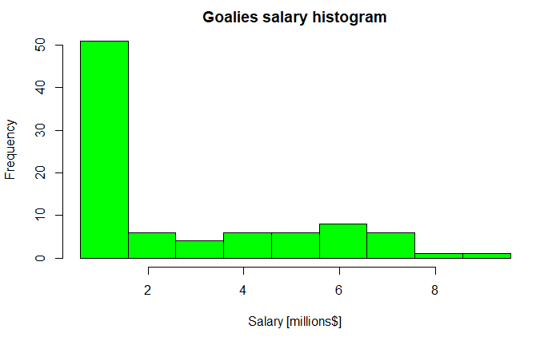

```r
histGoaliesSalary <- hist(goaliesSalary_pure$Salary,
         breaks = seq(min(goaliesSalary_pure$Salary),max(goaliesSalary_pure$Salary)+1, 1),
         main="Goalies salary histogram",
         xlab="Salary [millions$]",
         ylab = "Frequency",
         col="green"
         )
```

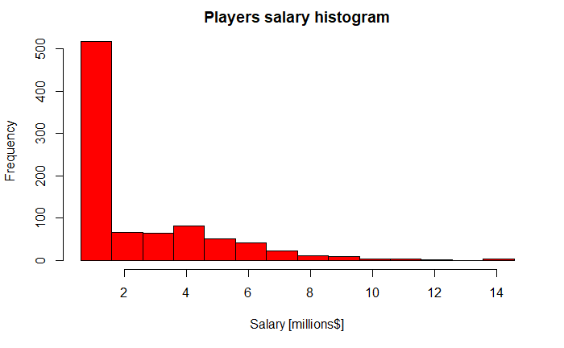

```r
histPlayersSalary <- hist(playersSalary_pure$Salary,
         breaks = seq(min(playersSalary_pure$Salary),max(playersSalary_pure$Salary)+1, 1),
         main="Players salary histogram",
         xlab="Salary [millions$]",
         ylab = "Frequency",
         col="red",
         )
```

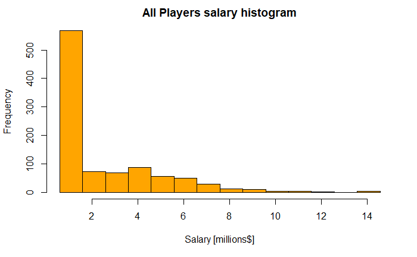

```r
histSalary <- hist(salary_pure$Salary,
         breaks = seq(min(salary_pure$Salary),max(salary_pure$Salary)+1, 1),
         main="All Players salary histogram",
         xlab="Salary [millions$]",
         ylab = "Frequency",
         col="orange",
         )
```

### Provjera log distribucije

S obzirom da iz histograma ne možemo uočiti normalnu distribuciju posluži ćemo se log distribucijom te tako transformirati podatake sve u svrhu donekle prikaza normalne distribucije.

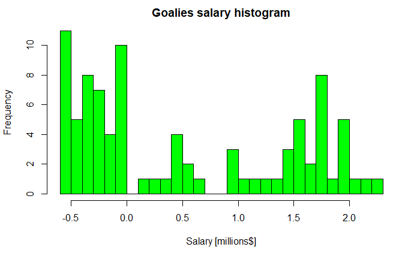

```r
hist(log(goaliesSalary_pure$Salary),
         breaks = 30,
         main="Goalies salary histogram",
         xlab="Salary [millions$]",
         ylab = "Frequency",
         col="green"
         )
```

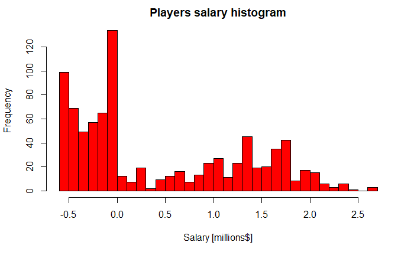

```r
hist(log(playersSalary_pure$Salary),
         breaks = 30,
         main="Players salary histogram",
         xlab="Salary [millions$]",
         ylab = "Frequency",
         col="red"
         )
```

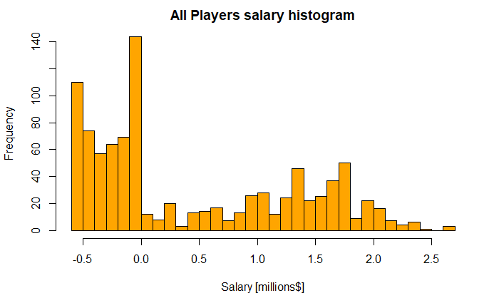

```r
hist(log(salary_pure$Salary),
         breaks = 30,
         main="All Players salary histogram",
         xlab="Salary [millions$]",
         ylab = "Frequency",
         col="orange",
         )
```

### qq plotovi

Iz histograma se ne može baš zaključiti dolazi li uzorak iz normalne distribucije te ćemo pokušati koristiti qq plotove.

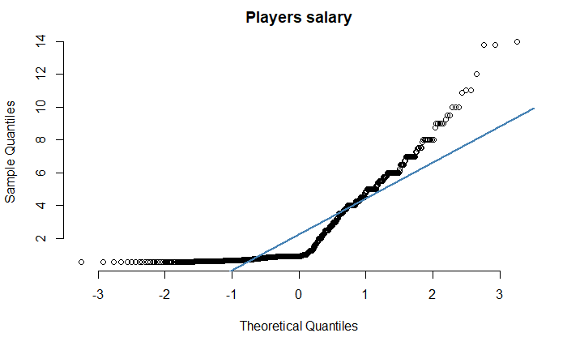

```r
qqnorm(playersSalary_pure$Salary, pch = 1, frame = FALSE,main='Players salary')
qqline(playersSalary_pure$Salary, col = "steelblue", lwd = 2)
```

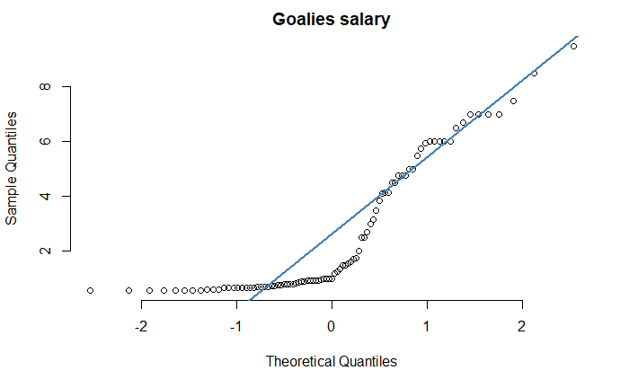

```r
qqnorm(goaliesSalary_pure$Salary, pch = 1, frame = FALSE,main='Goalies salary')
qqline(goaliesSalary_pure$Salary, col = "steelblue", lwd = 2)
```

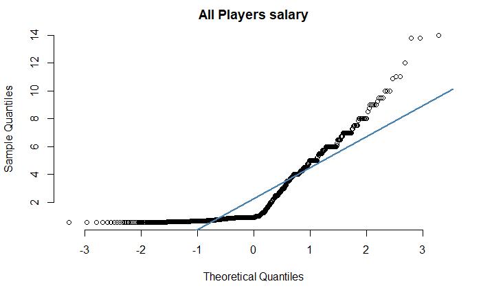

```r
qqnorm(salary_pure$Salary, pch = 1, frame = FALSE,main='All Players salary')
qqline(salary_pure$Salary, col = "steelblue", lwd = 2)
```

###ZAKLJUČAK  
QQ plotovi su pokazali istu stvar, ne možemo zaključiti da uzorak dolazi iz normalne distribucije. No ako ponovno malo bolje pogledamo u histogram mogli bi uočiti da uzorak dolazi iz eksponencijalne distribucije.

[figure not shown]

```r
hist(salary_pure$Salary,
         breaks = seq(min(salary_pure$Salary),max(salary_pure$Salary)+1, 1),
         main="Goalies salary histogram",
         xlab="Salary [millions$]",
         ylab = "Frequency",
         col="green",
         )
```

###ZADATAK 2 ## Provjerit ćemo jesu li igrači na centarskoj poziciji plaćeni više od obrambenih igrača.

Vrlo često u sportovima koje možemo podijeliti po mjestima na kojima igrači igraju na terenu(obrambeni,srednji i napadački dio) događa se da oni igrači koji su u napadu su većinom više plaćeni od drugi.Stoga će naš zadatak biti ispitati jesu li igači na centarskoj poziciji plaćeni više od obrambenih igrača.

```r
att = playersSalary_pure[playersSalary_pure$Position == "C" | playersSalary_pure$Position == "C/LW"| playersSalary_pure$Position == "C/LW/C" | playersSalary_pure$Position == "C/LW/RW" | playersSalary_pure$Position =="C/RW" | playersSalary_pure$Position == "C/RW/LW",]
def = playersSalary_pure[playersSalary_pure$Position == "D",]
```

Probat cemo prvo usporediti srednje vrijednosti:

```r
mean(att$Salary)
```

```
[1] 2.32232
```

```r
mean(def$Salary)
```

```
[1] 2.368636
```

Srednje vrijednosti su jako blizu, što nas navodi da su plaće centralnih i obrambenih igrača slične.

Iako iz histograma nismo mogli zaključiti da uzorak dolazi iz normalne distribucije, primjenom CGT možemo to zaključiti. Naime, promatramo stotine igrača što znači da je naš uzorak dovoljno velik, a i jasno je da su igrači međusobno nezavisni.

Provjerit ćemo jesu li varijance jednake:

```r
var(att$Salary)
```

```
[1] 6.282969
```

```r
var(def$Salary)
```

```
[1] 4.512176
```

Razlika nije nezamjeriva. Provodimo var.test()

```r
var.test(att$Salary, def$Salary)
```

```
    F test to compare two variances

data:  att$Salary and def$Salary
F = 1.3924, num df = 256, denom df = 291, p-value = 0.00623
alternative hypothesis: true ratio of variances is not equal to 1
95 percent confidence interval:
 1.098524 1.768258
sample estimates:
ratio of variances
          1.392448
```

p vrijednost iznosi 0.00623. Na temelju dobivene p vrijednosti odbacujemo H0 pretpostavku da su varijance jednake. Nastavljamo s računom uzimajući u obzir da nam varijance nisu jednake.

```r
t.test(att$Salary, def$Salary, alt="greater", var.equal = FALSE)
```

```
    Welch Two Sample t-test

data:  att$Salary and def$Salary
t = -0.23187, df = 504.56, p-value = 0.5916
alternative hypothesis: true difference in means is greater than 0
95 percent confidence interval:
 -0.37548      Inf
sample estimates:
mean of x mean of y
 2.322320  2.368636
```

###ZAKLJUČAK p-vrijednost iznosi 0.5916. To znači da ne odbacujemo pretpostavku da centralni igrači zarađuju jednako kao i obrambeni.

Rezultati su pomalo iznenađujući, uzimajući u obzir da u većini ostalih mainstream sportova napadači i igrači sredine zarađuju najviše novaca.